# Questionnaire Survival Analysis

## Questionnaire Data Set Analysis

The questionnaire section of the 2017-2020 NHANES data set has many different components, including questions on different social behaviours, health status, upbringing, medical history, environmental factors, and more. As there are almost 40 different factors explored, we decided to pick 5 that were of interest to us and/or mentioned in our literature review. The factors that we selected were: `alcohol consumption`, `depression`, `access to health care`, `insurance status`, and `occupation`. Alcohol is a prominent social behaviour that we thought would be interesting to explore in conjunction to diabetes as it is a integrated part of every culture. Depression appeared frequently in our literature review and we wanted to explore if there is any relationship between diabetes and depression within this data set. Access to health care and insurance status are related, and both are vital to diabetes treatment, which is why we decided to include them. Finally, we were curious about if employment status and how much someone works has any relationship with diabetes status, which is why we selected it as our final variable. The variables that weren’t selected are by no means of lesser importance to diabetes than the ones we chose. We selected only a few because we wanted to focus on a few variables in depth to get a comprehensive picture, rather than hastily exploring almost 40 variables.

Each one of the five subtopics is its own data set and has a series of individual questions within it. The alcohol data set explores general alcohol consumption behaviours, as well as quantifying how much alcohol someone consumes on average. The depression data set explores different specific feelings or states someone with depression may experience, such as difficulty sleeping, poor appetite, little will to do anything, etc. The access to health care explores how accessible health care is to the respondent including whether or not they have someone to go to receive health care regularly, and how frequently they receive health care. The insurance data set explores insurance coverage including general coverage, and what specific type of insurance an individual may have. Finally, the occupation data set explores topics such as job status, type of job, and how many hours the respondent works per week. All of these data sets have many variables and we were not able to explore all of them. Many of the variables are similar in nature and are quite specific. For example, in the alcohol data set, there are multiple questions about if the respondent has had 8+ drinks per day, and then another about whether they’ve had 6+ drinks per day. We felt that these variables didn’t provide as much information as some of the other ones, such as whether or not they’ve ever consumed alcohol or the average number of drinks per day. Therefore, for each data set, we selected a few variables that we felt summarised the topic effectively.

## Diabetes & Alcohol Analysis

The variables that we selected from the alcohol data set for the alcohol and diabetes analysis were `ever_had_a_drink_of_any_kind_of_alcohol` and `avg_alcoholic_drinks_per_day_past_12_months`. As mentioned above, we felt that these two variables summarised someone’s alcohol consumption effectively. As a reminder, the event of interest in the diabetes data set is `age_informed` and the time variable is `age_years`.

| term | estimate | std.error | statistic | p.value |
| --- | --- | --- | --- | --- |
| Ever Had Alcohol?: Yes | -0.0723713 | 0.09449305 | -0.7658901 | 0.4437417 |

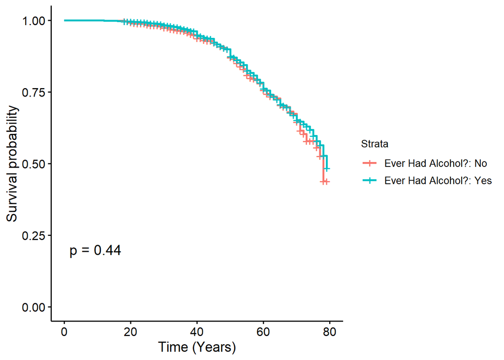

The alcohol and diabetes analysis shows us that consumption of alcohol altogether does not have a statistically significant impact on age informed of diabetes. The survival curves cross multiple times indicating that we are not able to tell if consumption of alcohol at least once in the respondent’s life has any relationship with when they are informed of their diabetes. This makes sense as “ever having a drink of alcohol” is quite a broad category. Some people in this category may only try alcohol once and never have it again, while others may drink every day. This prompted us to further explore alcohol consumption by looking at the average number of drinks per day over one year’s time span.

| term | estimate | std.error | statistic | p.value |
| --- | --- | --- | --- | --- |
| Average Alcoholic Drinks Per Day Past 12 Months | 0.04231258 | 0.01955076 | 2.164242 | 0.03044579 |

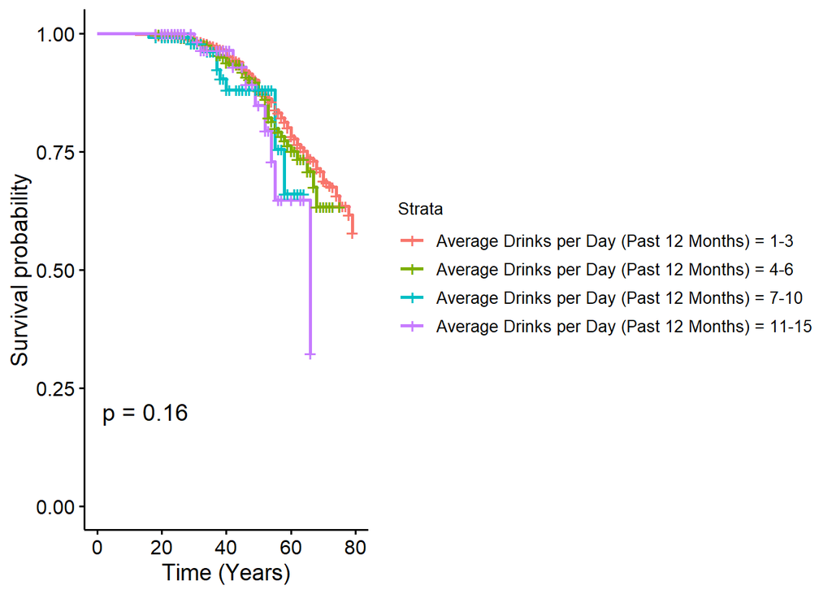

This Cox Regression model and the Kaplan-Meier curves show us different results. When we look at the Cox Regression model, we see an overall p-value of 0.03, which would make the relationship between consumption of alcohol and diabetes diagnosis statistically significant. However, when we look at the Kaplan-Meier curve, we do not see a statistically significant result between groups.

##### Table I: Average Number of Drinks per Day Past 12 Months Counts

| Number of Drinks | Count |
| --- | --- |
| 1 | 1996 |
| 2 | 1732 |
| 3 | 829 |
| 4 | 427 |
| 5 | 229 |
| 6 | 200 |
| 7 | 44 |
| 8 | 64 |
| 9 | 13 |
| 10 | 42 |
| 11 | 3 |
| 12 | 53 |
| 13 | 3 |
| 15 | 29 |

## Diabetes & Depression Analysis

For the diabetes and depression analysis, we selected four columns that we felt summarised many of the symptoms experienced by someone with depression: little interest in doing things, feeling down, depressed, or hopeless, feeling bad about yourself, and poor appetite or overeating. We want to acknowledge that, of course, these are not the only things that people with depression experience. Depression is a very dynamic and complicated condition that everyone experiences differently. We are unable to explore every aspect of it, so for the sake of our analysis, we chose a few variables that we thought were representative.

#### Little Interest in Doing Things

| term | estimate | std.error | statistic | p.value |
| --- | --- | --- | --- | --- |
| Little Interest in Doing Things: More than half the days | 0.11755932 | 0.1261548 | 0.9318654 | 0.3514061 |
| Little Interest in Doing Things: Not at all | 0.06391273 | 0.1402434 | 0.4557271 | 0.6485863 |
| Little Interest in Doing Things: Several days | NA | NA | NA | NA |

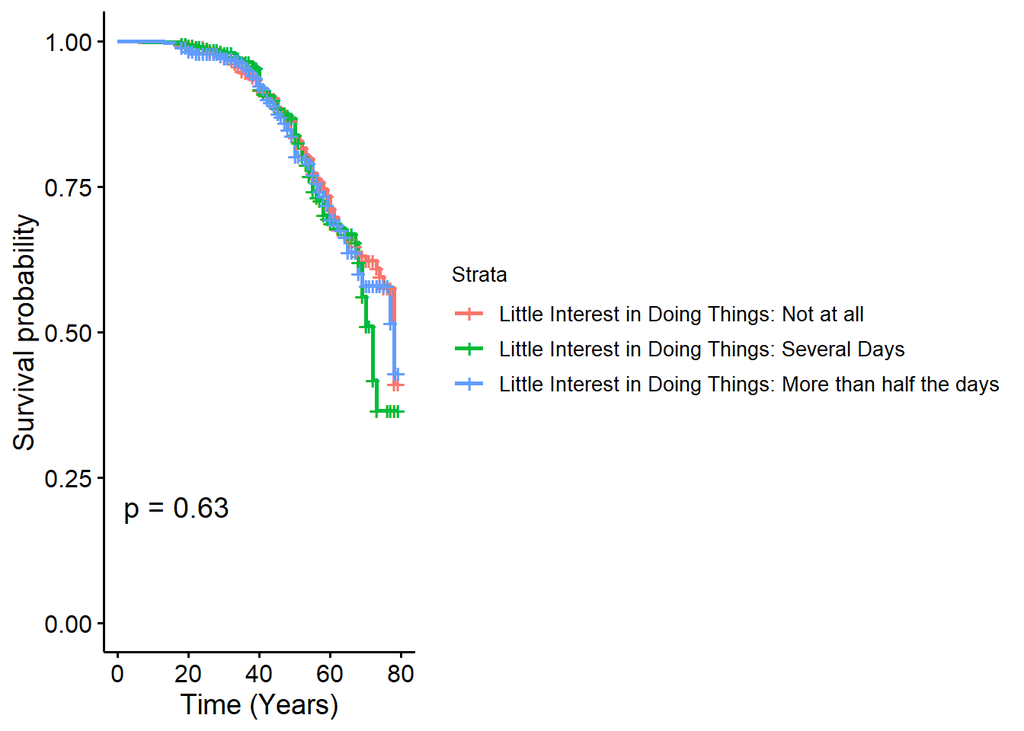

There didn’t seem to be any significant different in age informed of diabetes between groups who did not experience decreased interest in doing things, and those who did.

#### Feeling Down, Depressed, or Hopeless

| term | estimate | std.error | statistic | p.value |
| --- | --- | --- | --- | --- |
| Feeling Down, Depressed, or Hopeless: Not at all | -0.003496079 | 0.1425141 | -0.02453146 | 0.98042869 |
| Feeling Down, Depressed, or Hopeless: Several days | 0.303967538 | 0.1353904 | 2.24511846 | 0.02476053 |

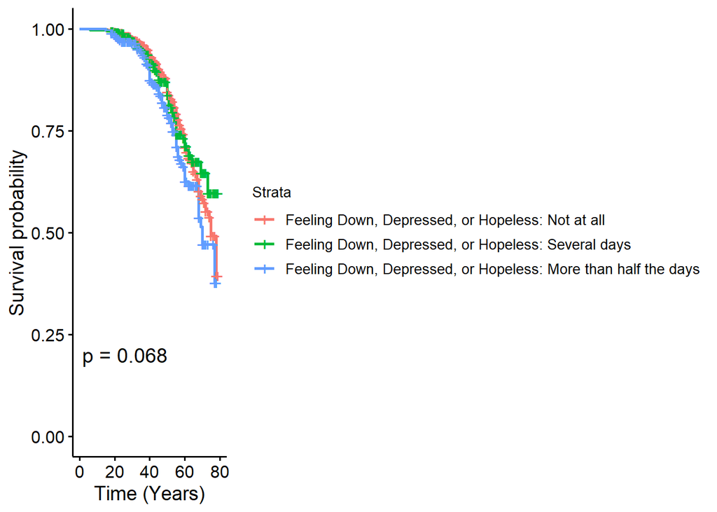

While the Kaplan-Meier curve did not show a statistically significant relationship between feeling down, depressed, and hopeless, and being diagnosed with diabetes, the Cox Regression model did for people who felt down, depressed, or hopeless on several days. The Kaplan-Meier curve was close to showing significance as it had a p-value of 0.06 at a significance level of 0.05. Because of the Cox Regression model showing significance, this variable will remain one of interest for our further analysis.

#### Feeling Bad About Yourself

| term | estimate | std.error | statistic | p.value |
| --- | --- | --- | --- | --- |
| Feeling Bad About Yourself: More than half the days | 0.3277865 | 0.1802633 | 1.818377 | 0.069006585 |
| Feeling Bad About Yourself: Not at all | 0.6007222 | 0.1627676 | 3.690674 | 0.000223661 |
| Feeling Bad About Yourself: Several days | NA | NA | NA | NA |

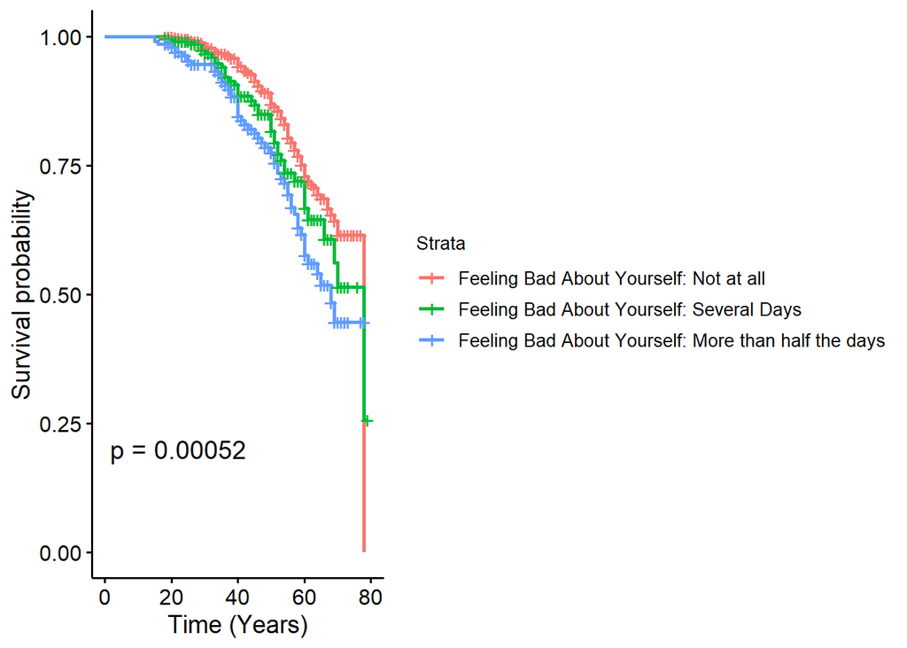

The Kaplan-Meier curves show that feeling bad about yourself does have a statistically significant relationship with age of diagnosis, with people who feel bad about themselves more than half the days tending to be diagnosed earlier and those who do not feel bad about themselves tending to be diagnosed later. This indicates an association with this symptom of depression and diabetes diagnosis.

#### Poor Appetite or Overeating

| term | estimate | std.error | statistic | p.value |
| --- | --- | --- | --- | --- |
| Poor Appetite or Overeating: Several days | 0.1020960 | 0.1267995 | 0.8051771 | 0.4207175 |
| Poor Appetite or Overeating: More than half the days | -0.1119409 | 0.1423234 | -0.7865247 | 0.4315601 |

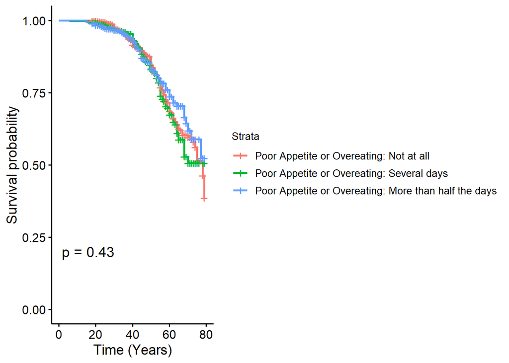

## Health Access and Hospital Use & Diabetes

For the health access and hospital use analysis, we selected only one variable: general health condition. Many of the other variables were quite specific and didn’t encompass a large amount of the data set and they related to specific hospital usage, so we felt that this variable encompassed the best overview of someone’s health access and condition.

#### General Health Condition

| term | estimate | std.error | statistic | p.value |
| --- | --- | --- | --- | --- |
| General Health Condition: Fair | 2.1102370 | 0.2051551 | 10.286056 | 8.144436e-25 |
| General Health Condition: Good | 1.7324696 | 0.2045147 | 8.471124 | 2.430373e-17 |
| General Health Condition: Poor | 2.4308160 | 0.2152149 | 11.294830 | 1.391732e-29 |
| General Health Condition: Very Good | 0.9475817 | 0.2136547 | 4.435109 | 9.202565e-06 |

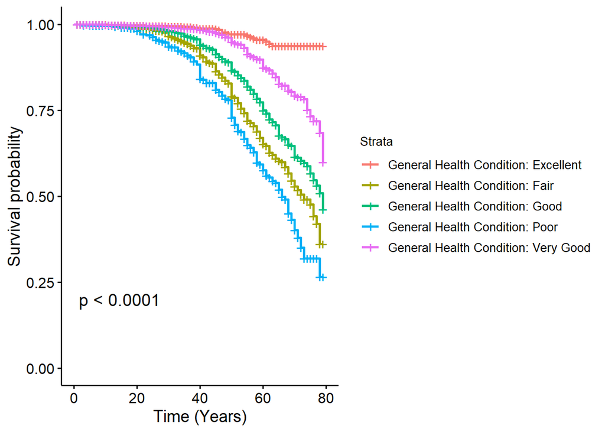

## Insurance and Diabetes Data

For the insurance data set, we chose the general insurance coverage question. We felt like knowing whether or not someone was covered by insurance was enough to assess their insurance situation. The rest of the variables asked what type of insurance they had, with almost 10 different insurance options to choose from, and we felt like those did not carry as much information.

#### Insurance Coverage

| term | estimate | std.error | statistic | p.value |
| --- | --- | --- | --- | --- |
| Covered by Health Insurance: No | -0.07726945 | 0.09218219 | -0.8382254 | 0.4019041 |

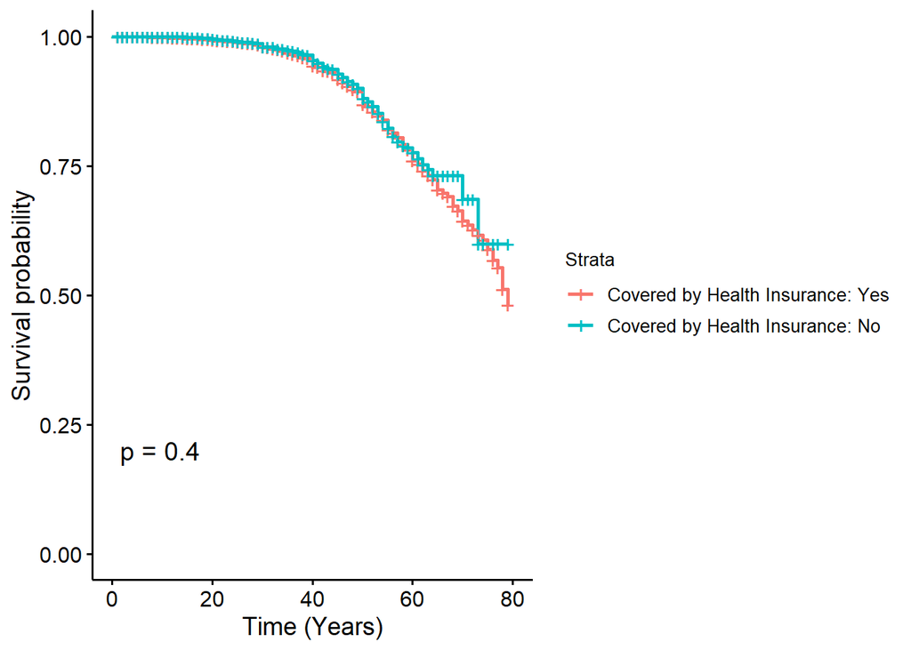

There is not a statistically significant difference in the age informed of diabetes between individuals who are and are not covered by health insurance.

## Occupation Data

Finally, for the occupation analysis, we selected type of job, which more indicates job status than type of work, as well as hours worked the previous week. We felt that these two variables adequately represented someone’s work status.

#### Type of Job

| term | estimate | std.error | statistic | p.value |
| --- | --- | --- | --- | --- |
| Type of Work Done Last Week: With a job or business but not at work | 0.03630974 | 0.22322015 | 0.1626634 | 8.707835e-01 |
| Type of Work Done Last Week: Not working at a job or business | 0.37126015 | 0.05932819 | 6.2577364 | 3.906052e-10 |
| Type of Work Done Last Week: Looking for work | 0.15945287 | 0.19475433 | 0.8187385 | 4.129356e-01 |

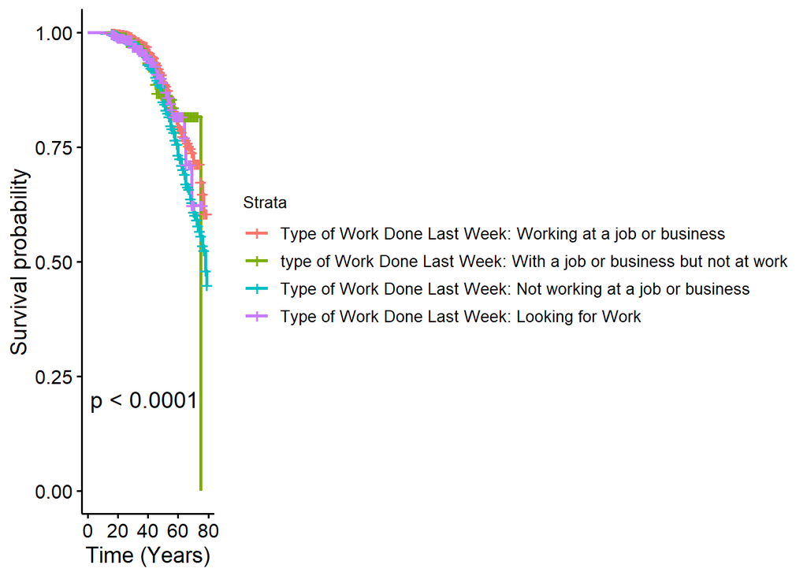

There is a statistically significant difference between work status and age informed of diabetes. It seems that those who are not working at a job or business tend to be informed of a diabetes diagnosis earlier than those who are working at a job or a business. It is important to consider why someone may be out of work, particularly if this reason is related to their health status.

#### Hours Worked

| term | estimate | std.error | statistic | p.value |
| --- | --- | --- | --- | --- |
| Hours Worked Last Week All Jobs: Overall | 0.1369793 | 0.3062994 | 0.4472072 | 0.65472548 |
| Hours Group: 21-30 | 0.2803927 | 0.2975018 | 0.9424906 | 0.34594154 |
| Hours Group: 31-40 | 0.3841613 | 0.2697668 | 1.4240497 | 0.15443210 |
| Hours Group: 41-50 | 0.2544395 | 0.2839111 | 0.8961944 | 0.37014893 |
| Hours Group: 51-60 | 0.6304088 | 0.2943813 | 2.1414704 | 0.03223612 |
| Hours Group: 61-70 | 0.5099801 | 0.3890884 | 1.3107050 | 0.18995746 |
| Hours Group: 71-80 | 0.1201793 | 0.4227005 | 0.2843132 | 0.77617038 |

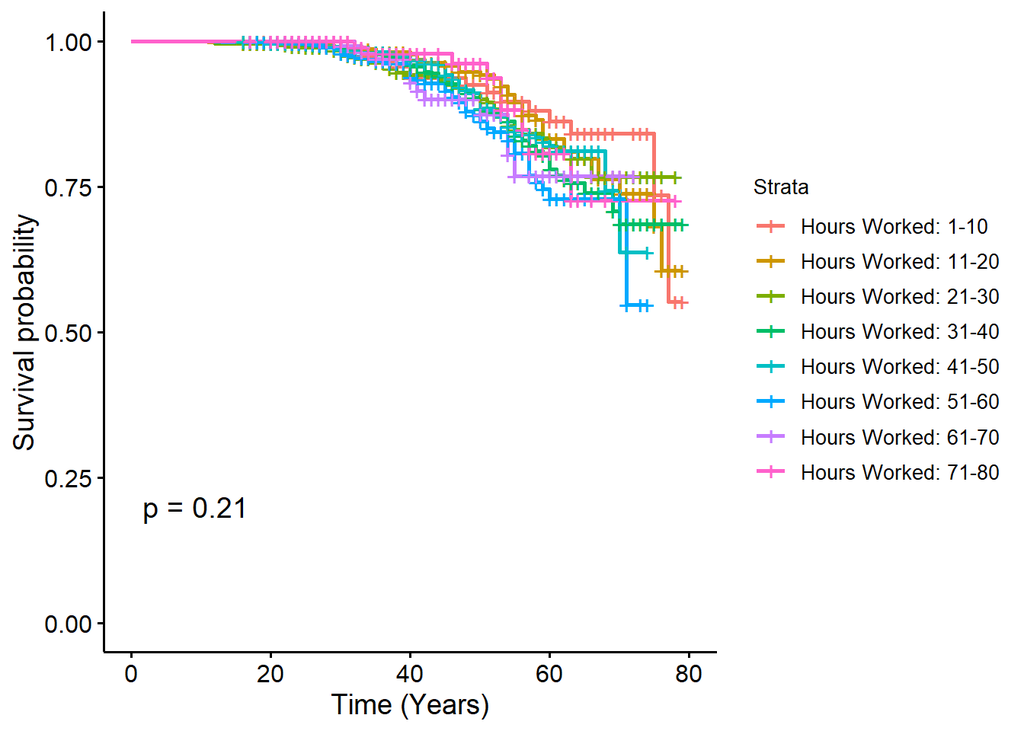